# NBA-statistikker 2022/2023

Asger Dalsgaard

2023-01-12

## Introduktion

Data på spillere er scrapet fra ESPN og hold-statistikker er scrapet fra Basketball-reference. Tallene er fra søndag d. 8. januar og kan opdateres på 2 minutter. Jeg har kun lavet, det jeg lige kunne komme i tanke om. Masser af muligheder!

> “One of those idiots, who believe in analytics… I always believed analytics are crap”

> — Charles Barkley

## Stjerner og superstjerner

En række plots med fokus på de bedst performende spillere på en række forskellige parametre

### Scoring champs

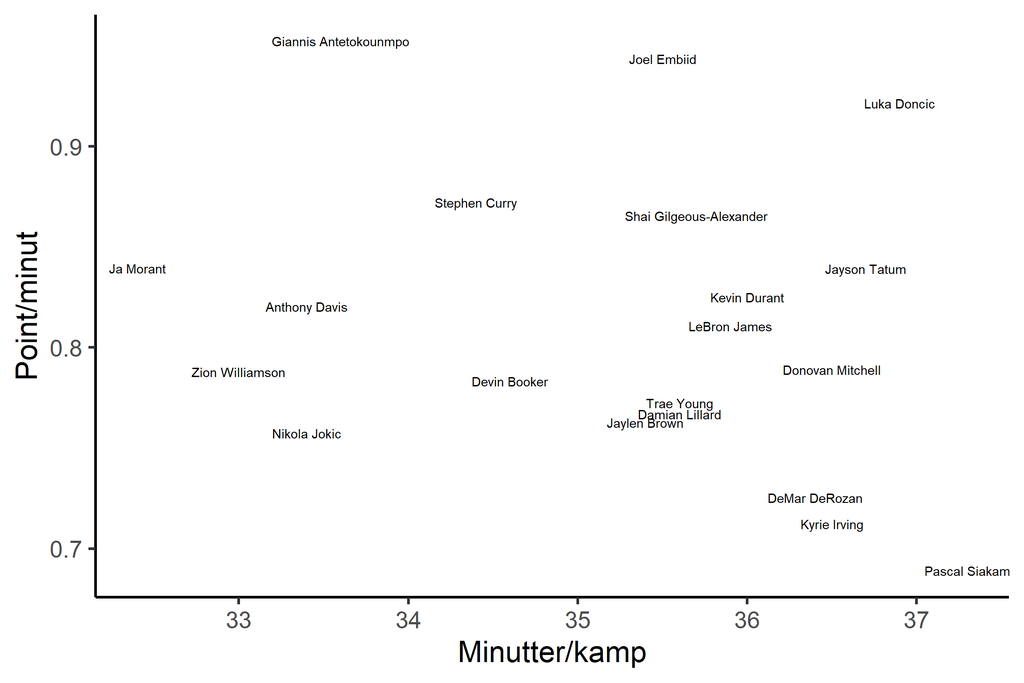

Plottet viser alle spillere, der scorer minimum 25p per kamp. I stedet for samlede antal point, korrigerer y-aksen for antal spillede minutter. Giannis er i denne optik den mest scorende spiller målt per spillet minut, tæt efterfulgt af Embiid og Doncic, som dog spiller en hel del flere minutter.

### Effektivitet: Effective field goal percentage

Ovenstående tager dog ikke højde for effektiviteten, men det gør nedenstående. Og her er billedet noget anerledes: Godt argument for at Jokic er sæsonens nuværende MPV. Kevin Durant holder til gengæld en høj eFG% SELVOM han spiller markant flere minutter end både Jokic/Curry/Williamson.

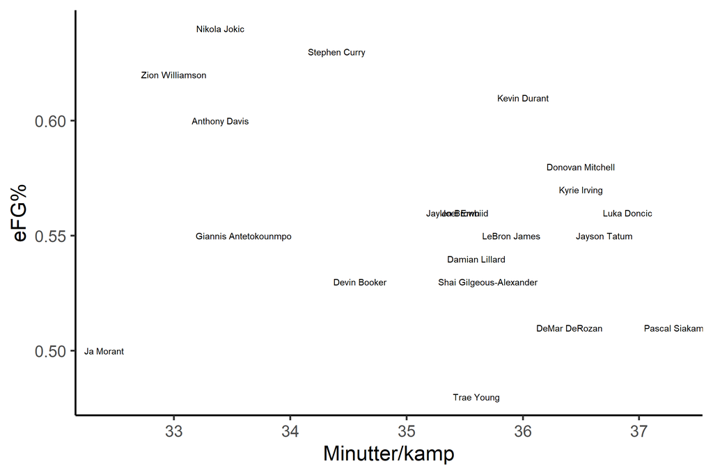

## Turnovers og assists

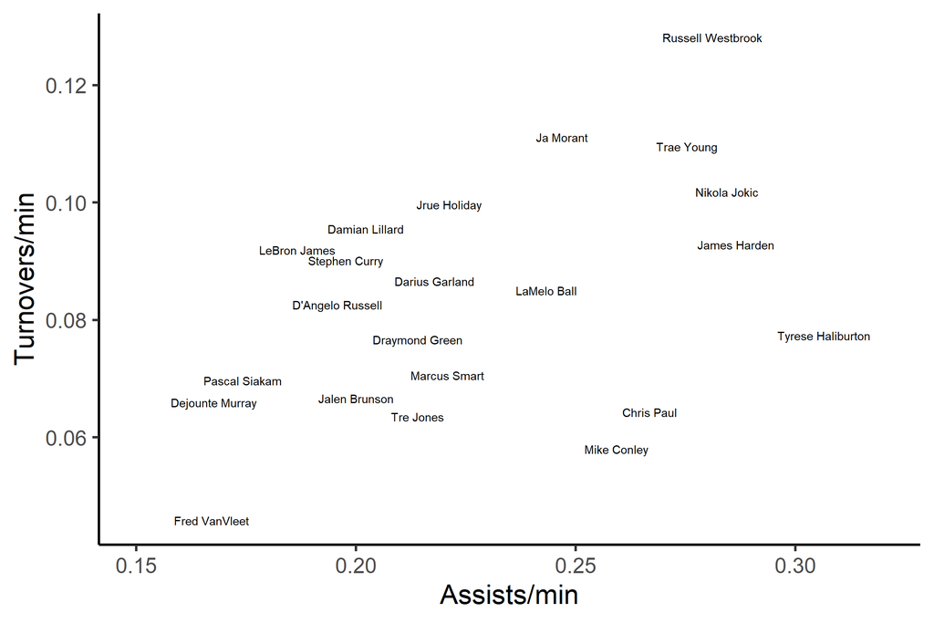

Kigger man kun på assists, er Haliburton faktisk den bedst afleverende spiller målt pr minut spillet - imponerende! Westbrook kunne ånde lettet op, hvis man kiggede på assists per kamp, men som bænkspiller får han færre minuter. Kigger man på turnovers per spillet minut ligger han øverst… .

## Holdprofiler: Hvem gør hvad?

Nedenstående plots hedder “spiderwebs”. Et web viser de 5 spillere fra et hold, som spiller flest minutter pr kamp (det vil typisk være starting lineup). Alle statistikker er korrigeret per spillet minut (dette kan selvfølgelig gøres pr kamp eller bare overall). Akserne er fastsat ud fra den spiller på holdet, som har leveret henholdsvis højest og lavest i den pågældende statistik. Grafen viser altså hvordan spillerne på holdet klarer sig INTERNT - ikke generelt i ligaen. Akserne er standardiserede, således korrigeres der for at ouputtet i nogle kategorier er lavere end andre (fx er blocks og steals meget mindre hyppige end scorede points). Det kan naturlivis diskuteres, hvordan output for hver statistik skal vægte.

Jeg har valgt følgende statistikker (alle per spillet minut): Assists, Steals, Blocks, Rebounds, Turnovers, Points (overall) og 3-pointscoringer,

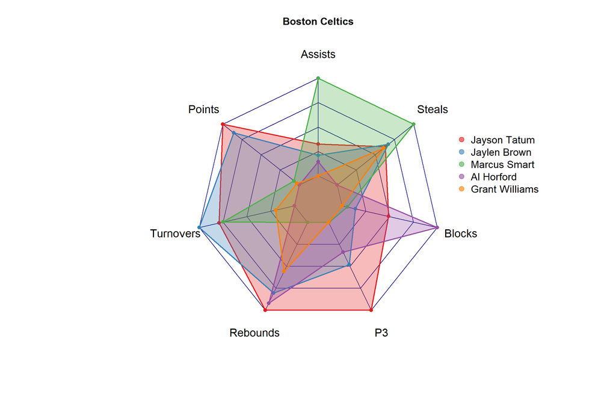

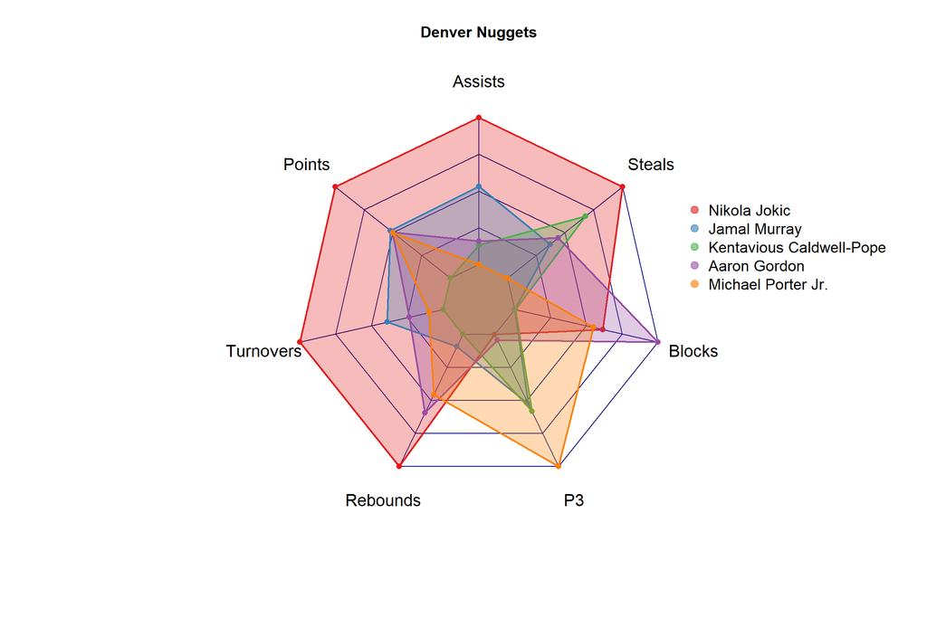

Jokic er stukket helt af, selvom der er flere gode spillere. Kun på 3-pointscoringer tager han sig en slapper. Dermed slipper han også for at løbe aaaaaalt for meget mellem kurven og 3-pointslinjen.

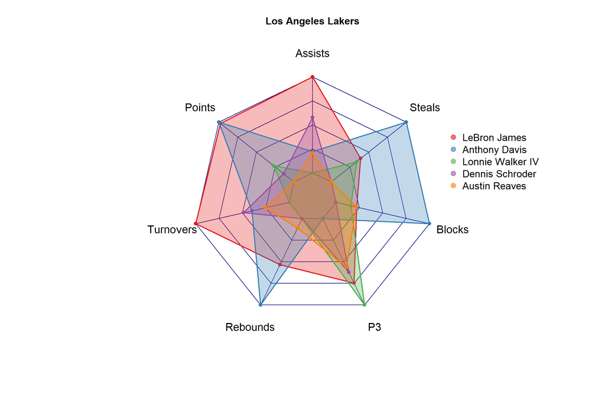

Uden Lebron og Day-To-Davies er Lakers ikke meget:

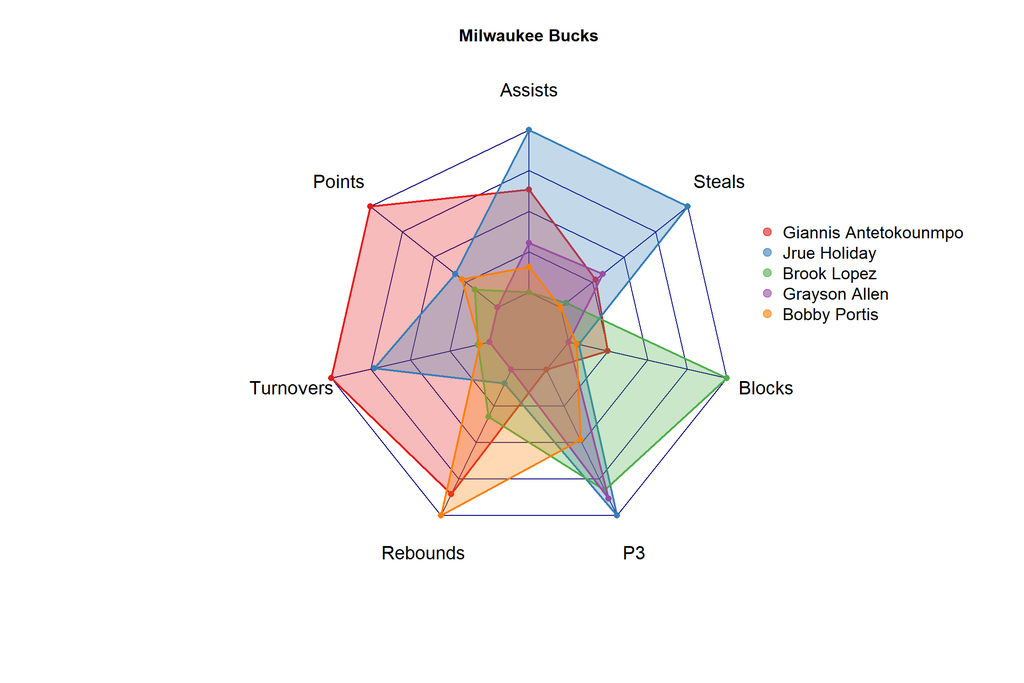

Milwaukee har omvendt et meget mere afbalanceret hold: Selvom Giannis gør det mest, får han markant hjælp fra Holiday, Portis og Lopez. Bemærk at Middleton ikke engang er 5. mest spillede spiller. De ser stærke ud. Lidt i stil med Milwaukke, har Pelicans også mange spillere, som leverer:

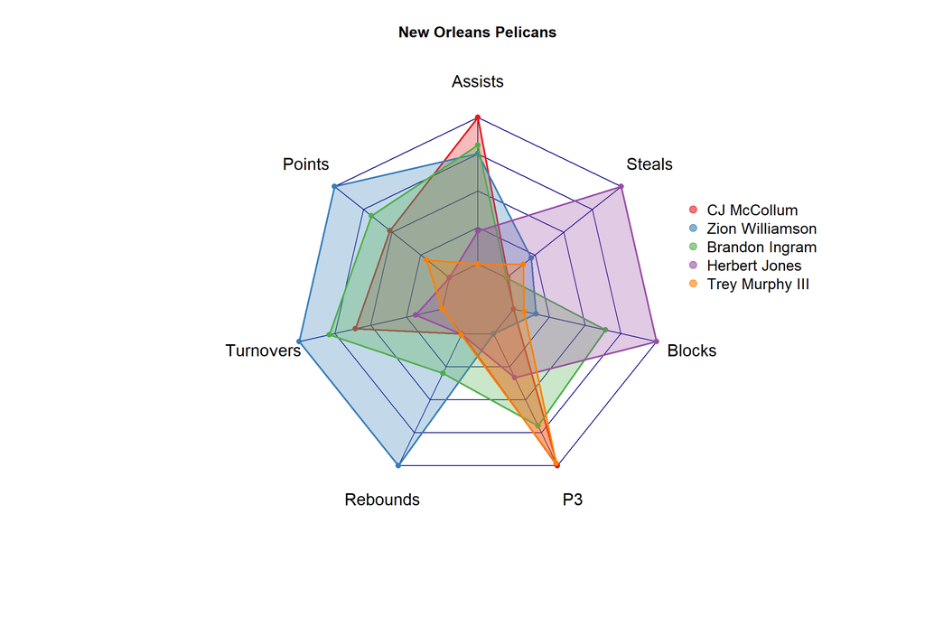

Brooklyn Nets har fået det de ønskede fra Ben Simmons. Forsvaret klarer ham og Claxton, imens Nr11 og Durant tager sig af klart de fleste point. Lige nu er “på pairet” blevet til virkelighed.

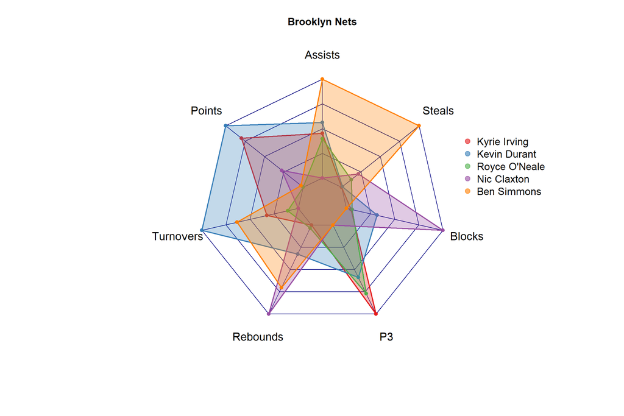

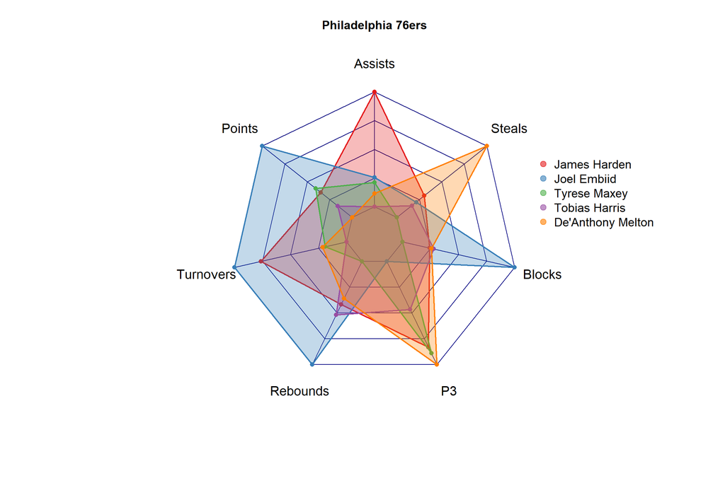

## Holdrankings

### Offensive/defensive rating

Bemærk at y-aksen med defensive rating er reversed: Lav defensive rating er bedst! Boston stikker helt af.

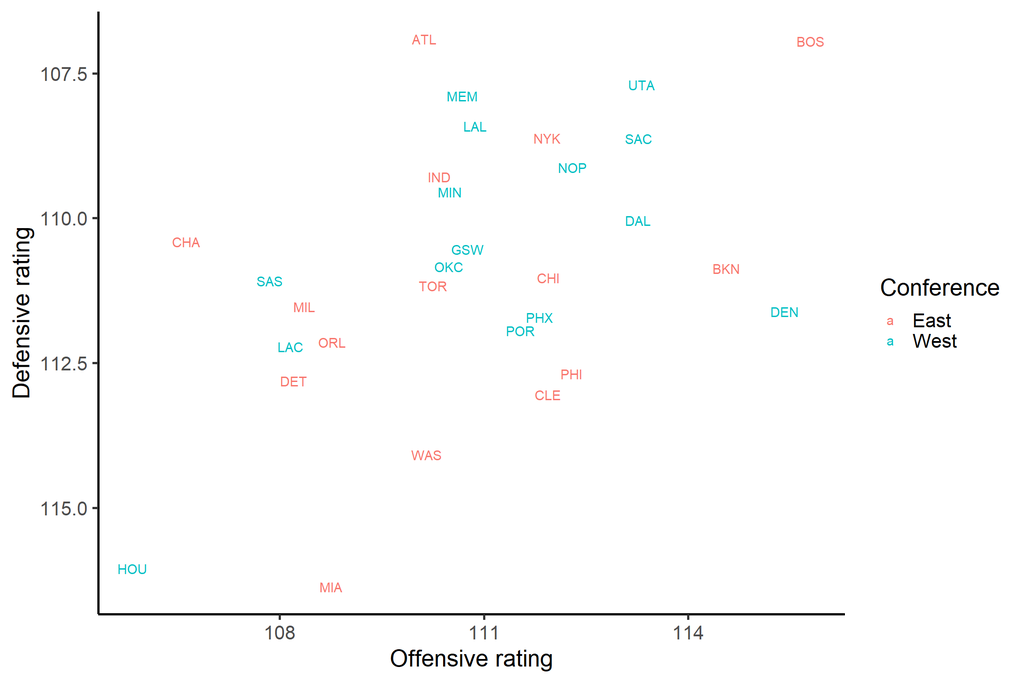

### Offensive og defensive pace

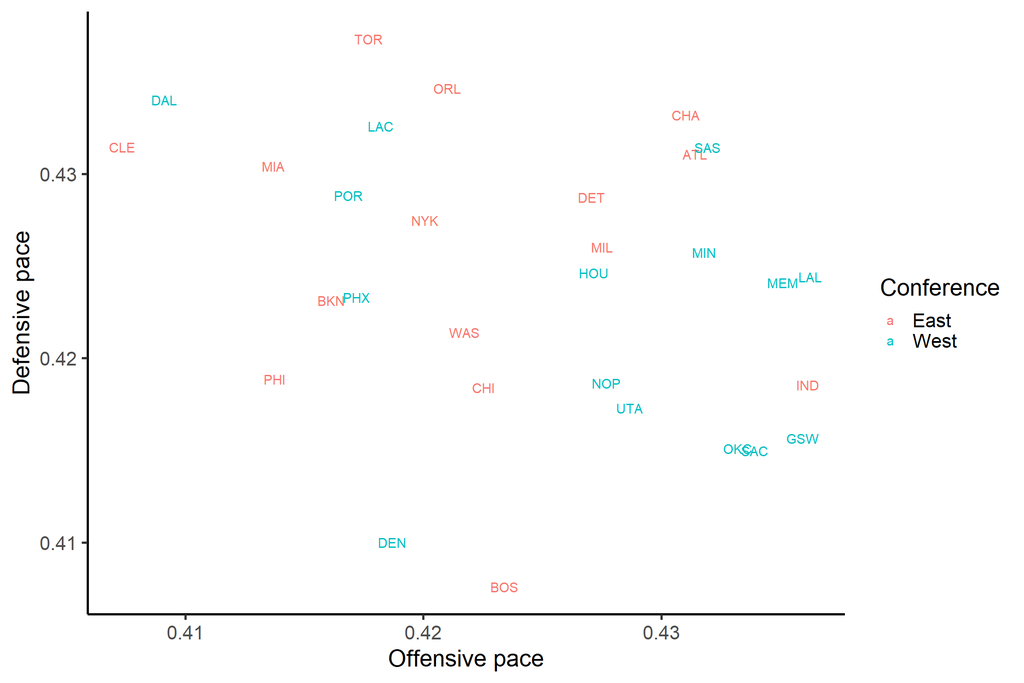

## Generelle spillerstatistikker

Statistikkerne for spillerkarakteristika er opdelt på hold, men kan også laves for fx position på banen.

### Højde

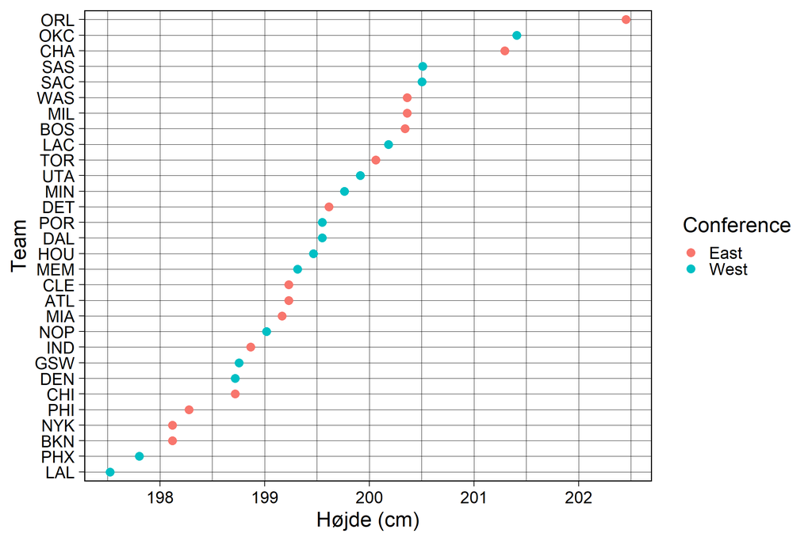

### Drøjde

Ved at tage højde for spillerens vægt, korrigeres grafen for højde her til “drøjde”: “Hvor mange kilo vejer spillerne i gennemsnit pr centimeter?

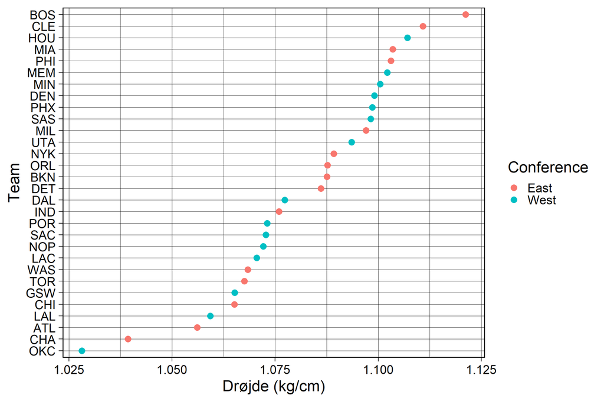

OKC-spillerne var det andet højeste hold, men i drøjde er de klart mindst. Givetvis fordi de er så unge og splejsede!

Gennemsnitslønnen for holdenes spillere. Holdene med de store stjerner, ligger selvfølgelig i toppen. Måske lidt overraskende ligger Dallas meget højt?

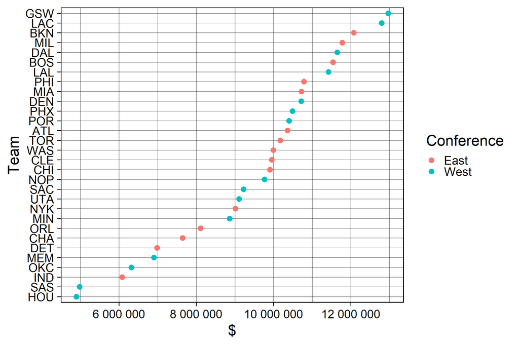